# Analysis: Exploratory Data Analysis

## Introduction

This markdown imports the processed data and conducts the exploratory data analysis. Follow the processing markdowns in the `processing_code` folder to generate the processed data.

This analysis examines the predictors of performance on the code survey. In terms of the dataset, the three (potential) outcomes of interest are Overall Grade (`GradeOverall`), Code Type Grade (`GradeType`), and Code Answer Grade (`CodeScore`).

It also creates the summary table in the manuscript.

## Required Packages

The following R packages are required for this script:

- here: for path setting
- tidyverse: for all packages in the Tidyverse (ggplot2, dyplr, tidyr, readr, purr, tibble, stringr, forcats)
- skimr: for data summarization
- summarytools: for overall dataframe summary
- car: for creating QQ plots
- gtsummary: for creating tables for summary statistics / other numerical outputs
- flextable: for outputting tables in word
- extrafont: for changing the font of ggplots

## Load Processed Data

Load the data generated from the markdowns in the `processing_code` folder.

```r
#define file path
data_location <- here::here("data", "processed_data", "full_processed.rds")

#load data
EDAdata <- readRDS(data_location)
```

## Data Overview

To better understand the data, let’s use `summarytools` to better visualize the data.

```r
summarytools::dfSummary(EDAdata)
```

```
## Data Frame Summary
## EDAdata
## Dimensions: 304 x 55
## Duplicates: 0
##
## --------------------------------------------------------------------------------------------------------------------------------------------------------------------------
## No   Variable                   Label                                     Stats / Values                  Freqs (% of Valid)   Graph                  Valid      Missing
## ---- -------------------------- ----------------------------------------- ------------------------------- -------------------- ---------------------- ---------- ---------
## 1    FacilityLabel              Facility                                  1. A                            99 (32.6%)           IIIIII                 304        0
##      [factor]                                                             2. B                            21 ( 6.9%)           I                      (100.0%)   (0.0%)
##                                                                           3. C                            59 (19.4%)           III
##                                                                           4. D                            78 (25.7%)           IIIII
##                                                                           5. E                            47 (15.5%)           III
##
## 2    PositionType               Position Type                             1. Clinical                     196 (64.5%)          IIIIIIIIIIII           304        0
##      [factor]                                                             2. Non-clinical                 108 (35.5%)          IIIIIII                (100.0%)   (0.0%)
##
## 3    HealthcareYears            Healthcare Experience                     1. 0-2 years                     51 (16.8%)          III                    304        0
##      [factor]                                                             2. 2-5 years                     67 (22.0%)          IIII                   (100.0%)   (0.0%)
##                                                                           3. 5-8 years                     37 (12.2%)          II
##                                                                           4. > 8 years                    149 (49.0%)          IIIIIIIII
##
## 4    FacilityYears              Facility Experience                       1. 0-2 years                     90 (29.6%)          IIIII                  304        0
##      [factor]                                                             2. 2-5 years                     77 (25.3%)          IIIII                  (100.0%)   (0.0%)
##                                                                           3. 5-8 years                     32 (10.5%)          II
##                                                                           4. > 8 years                    105 (34.5%)          IIIIII
##
## 5    FacilitiesNumber           Total Facilities in Career                1. 1 facility                   123 (40.5%)          IIIIIIII               304        0
##      [factor]                                                             2. 2-3 facilities               106 (34.9%)          IIIIII                 (100.0%)   (0.0%)
##                                                                           3. 4-5 facilities                42 (13.8%)          II
##                                                                           4. > 5 facilities                33 (10.9%)          II
##
## 6    ShiftType                  Typical Shift                             1. Day Shift                    279 (91.8%)          IIIIIIIIIIIIIIIIII     304        0
##      [factor]                                                             2. Night Shift                    5 ( 1.6%)                                 (100.0%)   (0.0%)
##                                                                           3. Equal times on both shift     20 ( 6.6%)          I
##
## 7    PreConfidence              Pre-Survey Confidence Score               Mean (sd) : 5.4 (1.2)           1 :  1 ( 0.3%)                              304        0
##      [numeric]                                                            min < med < max:                2 :  4 ( 1.3%)                              (100.0%)   (0.0%)
##                                                                           1 < 5 < 7                       3 : 11 ( 3.6%)
##                                                                           IQR (CV) : 2 (0.2)              4 : 63 (20.7%)       IIII
```

[output cut: 224 more lines]

```
##      [numeric]                                                            min < med < max:                                         :   :              (100.0%)   (0.0%)
##                                                                           0 < 42.9 < 100                                           : : :
##                                                                           IQR (CV) : 28.6 (0.4)                                    : : : :   :
##                                                                                                                                  : : : : : : : . .
##
## 55   Delta                      Change in Confidence Score                Mean (sd) : -0.9 (1.2)          -5 :   1 ( 0.3%)                            304        0
##      [numeric]                                                            min < med < max:                -4 :   6 ( 2.0%)                            (100.0%)   (0.0%)
##                                                                           -5 < -1 < 3                     -3 :  16 ( 5.3%)     I
##                                                                           IQR (CV) : 2 (-1.3)             -2 :  63 (20.7%)     IIII
##                                                                                                           -1 :  86 (28.3%)     IIIII
##                                                                                                           0 : 112 (36.8%)      IIIIIII
##                                                                                                           1 :  16 ( 5.3%)      I
##                                                                                                           2 :   3 ( 1.0%)
##                                                                                                           3 :   1 ( 0.3%)
## --------------------------------------------------------------------------------------------------------------------------------------------------------------------------
```

```r
skimr::skim(EDAdata)
```

Data summary

| Name | EDAdata |
| --- | --- |
| Number of rows | 304 |
| Number of columns | 55 |
| _______________________ |  |
| Column type frequency: |  |
| character | 5 |
| factor | 15 |
| numeric | 35 |
| ________________________ |  |
| Group variables | None |

**Variable type: character**

| skim_variable | n_missing | complete_rate | min | max | empty | n_unique | whitespace |
| --- | --- | --- | --- | --- | --- | --- | --- |
| ECE | 101 | 0.67 | 2 | 330 | 0 | 188 | 0 |
| PLcodeswhy | 169 | 0.44 | 2 | 628 | 0 | 129 | 0 |
| CodeexceptionsID | 93 | 0.69 | 2 | 341 | 0 | 198 | 0 |
| TrainingOtherCat | 0 | 1.00 | 2 | 2 | 0 | 1 | 0 |
| Trainingother | 276 | 0.09 | 3 | 154 | 0 | 28 | 0 |

**Variable type: factor**

| skim_variable | n_missing | complete_rate | ordered | n_unique | top_counts |
| --- | --- | --- | --- | --- | --- |
| FacilityLabel | 0 | 1 | FALSE | 5 | A: 99, D: 78, C: 59, E: 47 |
| PositionType | 0 | 1 | FALSE | 2 | Cli: 196, Non: 108 |
| HealthcareYears | 0 | 1 | FALSE | 4 | > 8: 149, 2-5: 67, 0-2: 51, 5-8: 37 |
| FacilityYears | 0 | 1 | FALSE | 4 | > 8: 105, 0-2: 90, 2-5: 77, 5-8: 32 |
| FacilitiesNumber | 0 | 1 | FALSE | 4 | 1 f: 123, 2-3: 106, 4-5: 42, > 5: 33 |
| ShiftType | 0 | 1 | FALSE | 3 | Day: 279, Equ: 20, Nig: 5 |
| CodeProcedures | 0 | 1 | FALSE | 2 | Yes: 210, No: 94 |
| CodePreference | 0 | 1 | FALSE | 2 | Col: 199, Pla: 105 |
| Codeexceptions | 0 | 1 | FALSE | 2 | Yes: 240, No: 64 |
| TrainingOrientation | 0 | 1 | FALSE | 2 | Yes: 208, No: 96 |
| TrainingYearly | 0 | 1 | FALSE | 2 | Yes: 155, No: 149 |
| TrainingExercises | 0 | 1 | FALSE | 2 | Yes: 169, No: 135 |
| Traininglasttime | 0 | 1 | FALSE | 4 | 1-6: 113, 6-1: 83, > 1: 57, < 1: 51 |
| Facilitiesdifferentcodes | 0 | 1 | FALSE | 3 | No: 197, Yes: 80, May: 27 |
| Codeconfusion | 0 | 1 | FALSE | 2 | No: 196, Yes: 108 |

**Variable type: numeric**

| skim_variable | n_missing | complete_rate | mean | sd | p0 | p25 | p50 | p75 | p100 | hist |
| --- | --- | --- | --- | --- | --- | --- | --- | --- | --- | --- |
| PreConfidence | 0 | 1 | 5.36 | 1.24 | 1.00 | 4.00 | 5.00 | 6.00 | 7.00 | ▁▁▃▅▇ |
| FireType | 0 | 1 | 0.95 | 0.22 | 0.00 | 1.00 | 1.00 | 1.00 | 1.00 | ▁▁▁▁▇ |
| FireAnswer | 0 | 1 | 0.96 | 0.19 | 0.00 | 1.00 | 1.00 | 1.00 | 1.00 | ▁▁▁▁▇ |
| CAType | 0 | 1 | 0.89 | 0.31 | 0.00 | 1.00 | 1.00 | 1.00 | 1.00 | ▁▁▁▁▇ |
| CAAnswer | 0 | 1 | 0.90 | 0.30 | 0.00 | 1.00 | 1.00 | 1.00 | 1.00 | ▁▁▁▁▇ |
| PedsType | 0 | 1 | 0.11 | 0.31 | 0.00 | 0.00 | 0.00 | 0.00 | 1.00 | ▇▁▁▁▁ |
| PedsAnswer | 0 | 1 | 0.11 | 0.31 | 0.00 | 0.00 | 0.00 | 0.00 | 1.00 | ▇▁▁▁▁ |
| BombType | 0 | 1 | 0.74 | 0.44 | 0.00 | 0.00 | 1.00 | 1.00 | 1.00 | ▃▁▁▁▇ |
| BombAnswer | 0 | 1 | 0.31 | 0.46 | 0.00 | 0.00 | 0.00 | 1.00 | 1.00 | ▇▁▁▁▃ |
| ViolenceType | 0 | 1 | 0.59 | 0.49 | 0.00 | 0.00 | 1.00 | 1.00 | 1.00 | ▆▁▁▁▇ |
| ViolenceAnswer | 0 | 1 | 0.43 | 0.50 | 0.00 | 0.00 | 0.00 | 1.00 | 1.00 | ▇▁▁▁▆ |
| ASType | 0 | 1 | 0.80 | 0.40 | 0.00 | 1.00 | 1.00 | 1.00 | 1.00 | ▂▁▁▁▇ |
| ASAnswer | 0 | 1 | 0.68 | 0.47 | 0.00 | 0.00 | 1.00 | 1.00 | 1.00 | ▃▁▁▁▇ |
| InfantType | 0 | 1 | 0.93 | 0.25 | 0.00 | 1.00 | 1.00 | 1.00 | 1.00 | ▁▁▁▁▇ |
| InfantAnswer | 0 | 1 | 0.91 | 0.28 | 0.00 | 1.00 | 1.00 | 1.00 | 1.00 | ▁▁▁▁▇ |
| MCIType | 0 | 1 | 0.31 | 0.46 | 0.00 | 0.00 | 0.00 | 1.00 | 1.00 | ▇▁▁▁▃ |
| MCIAnswer | 0 | 1 | 0.04 | 0.20 | 0.00 | 0.00 | 0.00 | 0.00 | 1.00 | ▇▁▁▁▁ |
| IDType | 0 | 1 | 0.21 | 0.41 | 0.00 | 0.00 | 0.00 | 0.00 | 1.00 | ▇▁▁▁▂ |
| IDAnswer | 0 | 1 | 0.15 | 0.36 | 0.00 | 0.00 | 0.00 | 0.00 | 1.00 | ▇▁▁▁▂ |
| HazMatType | 0 | 1 | 0.65 | 0.48 | 0.00 | 0.00 | 1.00 | 1.00 | 1.00 | ▅▁▁▁▇ |
| HazMatAnswer | 0 | 1 | 0.49 | 0.50 | 0.00 | 0.00 | 0.00 | 1.00 | 1.00 | ▇▁▁▁▇ |
| MAType | 0 | 1 | 0.33 | 0.47 | 0.00 | 0.00 | 0.00 | 1.00 | 1.00 | ▇▁▁▁▃ |
| MAAnswer | 0 | 1 | 0.26 | 0.44 | 0.00 | 0.00 | 0.00 | 1.00 | 1.00 | ▇▁▁▁▃ |
| SWType | 0 | 1 | 0.53 | 0.50 | 0.00 | 0.00 | 1.00 | 1.00 | 1.00 | ▇▁▁▁▇ |
| SWAnswer | 0 | 1 | 0.42 | 0.49 | 0.00 | 0.00 | 0.00 | 1.00 | 1.00 | ▇▁▁▁▆ |
| MCType | 0 | 1 | 0.73 | 0.44 | 0.00 | 0.00 | 1.00 | 1.00 | 1.00 | ▃▁▁▁▇ |
| MCAnswer | 0 | 1 | 0.42 | 0.49 | 0.00 | 0.00 | 0.00 | 1.00 | 1.00 | ▇▁▁▁▆ |
| HSType | 0 | 1 | 0.28 | 0.45 | 0.00 | 0.00 | 0.00 | 1.00 | 1.00 | ▇▁▁▁▃ |
| HSAnswer | 0 | 1 | 0.15 | 0.36 | 0.00 | 0.00 | 0.00 | 0.00 | 1.00 | ▇▁▁▁▂ |
| GradeOverall | 0 | 1 | 0.51 | 0.17 | 0.07 | 0.39 | 0.50 | 0.64 | 0.96 | ▂▇▇▅▂ |
| GradeType | 0 | 1 | 0.58 | 0.17 | 0.07 | 0.50 | 0.57 | 0.71 | 1.00 | ▁▅▇▇▂ |
| CodeScore | 0 | 1 | 0.45 | 0.19 | 0.00 | 0.29 | 0.43 | 0.57 | 1.00 | ▁▇▇▃▁ |
| PostConfidence | 0 | 1 | 4.49 | 1.55 | 1.00 | 3.00 | 5.00 | 6.00 | 7.00 | ▃▃▆▇▇ |
| CodeScorePct | 0 | 1 | 44.50 | 19.26 | 0.00 | 28.57 | 42.86 | 57.14 | 100.00 | ▁▇▇▃▁ |
| Delta | 0 | 1 | -0.87 | 1.16 | -5.00 | -2.00 | -1.00 | 0.00 | 3.00 | ▁▅▆▇▁ |

Looking at the output of `summarytools::dfsummary()`

- There are 304 completed survey responses
- `GradeOverall` ranges from 0.1 to 1, with a mean of 0.5
- `GradeType` ranges from 0.1 to 1, with a mean of 0.6
- `CodeScore` ranges from 0 to 1, with a mean of 0.4
- There still appears to be a preference to keep color codes

Let’s dive a little deeper into each variable.

## Outcome of Interest: Overall Performance

The first potential outcome of interest is the overall performance across all survey questions.

```r
#summary statistics
base::summary(EDAdata$`GradeOverall`)
```

```
##    Min. 1st Qu.  Median    Mean 3rd Qu.    Max.
## 0.07143 0.39286 0.50000 0.51022 0.64286 0.96429
```

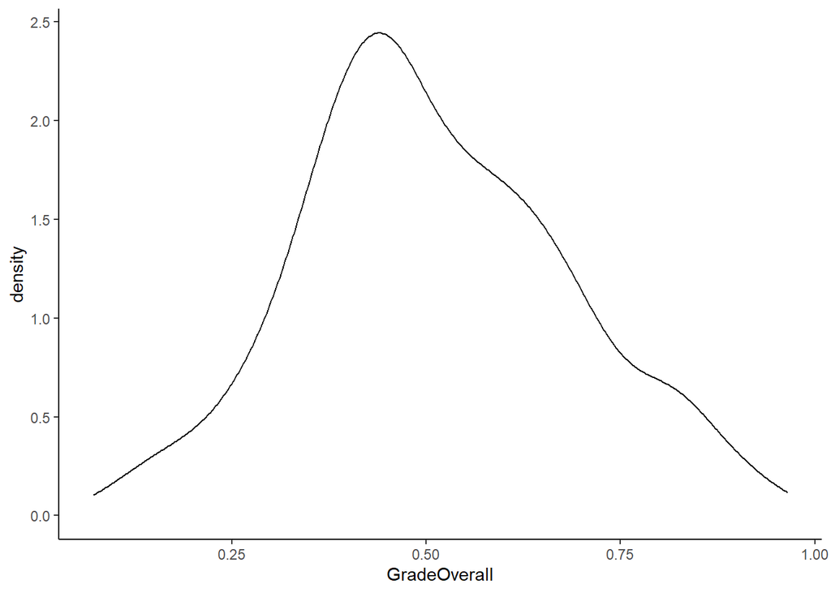

```r
#density plot
ggplot2::ggplot(data = EDAdata, aes(x = `GradeOverall`)) +
  geom_density()
```

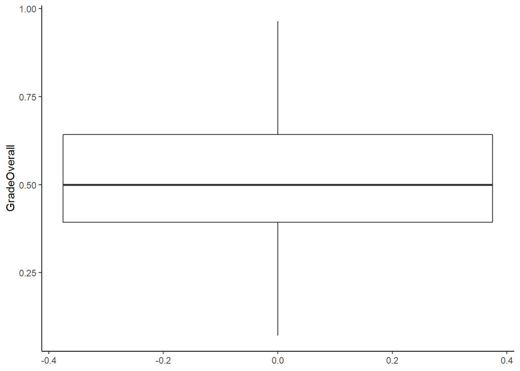

```r
#normal boxplot
ggplot2::ggplot(data = EDAdata, aes(y = `GradeOverall`)) +
  geom_boxplot()
```

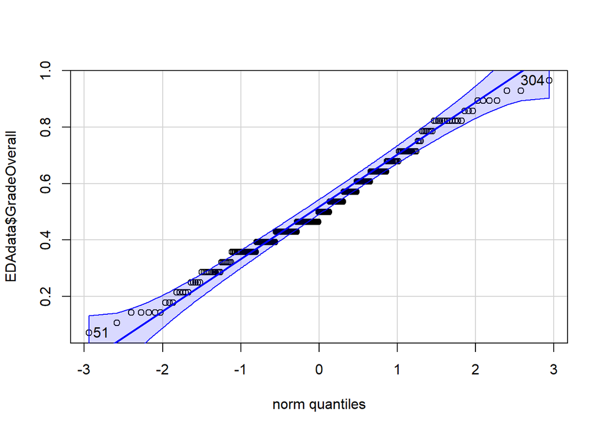

```
## [1] 304  51
```

```r
##QQ plot
car::qqPlot(EDAdata$`GradeOverall`)
```

These outputs show the overall performance is relatively normally distributed. There really don’t seem to be any outliers, and it does not appear to require any transformation.

## Outcome of Interest: Code Type Performance

The next potential outcome of interest is the performance across survey questions that asked about the type of code for each hazard.

```r
#summary statistics
base::summary(EDAdata$`GradeType`)
```

```
##    Min. 1st Qu.  Median    Mean 3rd Qu.    Max.
## 0.07143 0.50000 0.57143 0.57542 0.71429 1.00000
```

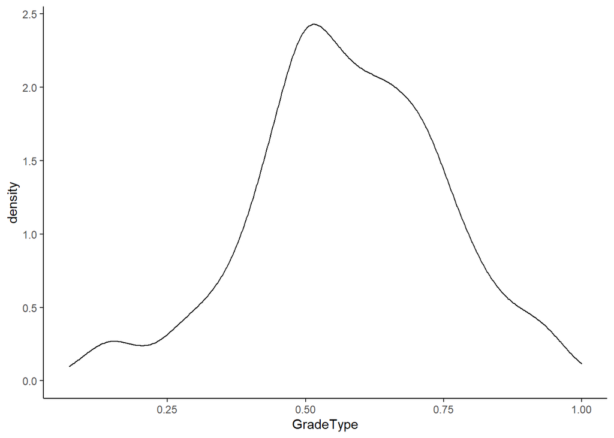

```r
#density plot
ggplot2::ggplot(data = EDAdata, aes(x = `GradeType`)) +
  geom_density()
```

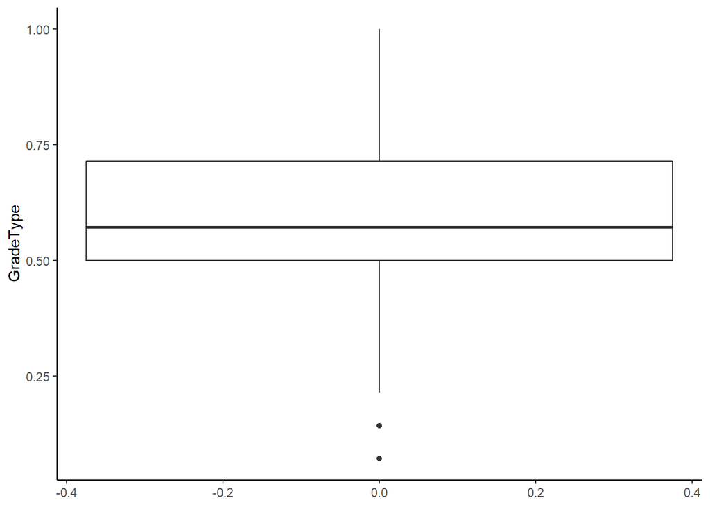

```r
#normal boxplot
ggplot2::ggplot(data = EDAdata, aes(y = `GradeType`)) +
  geom_boxplot()
```

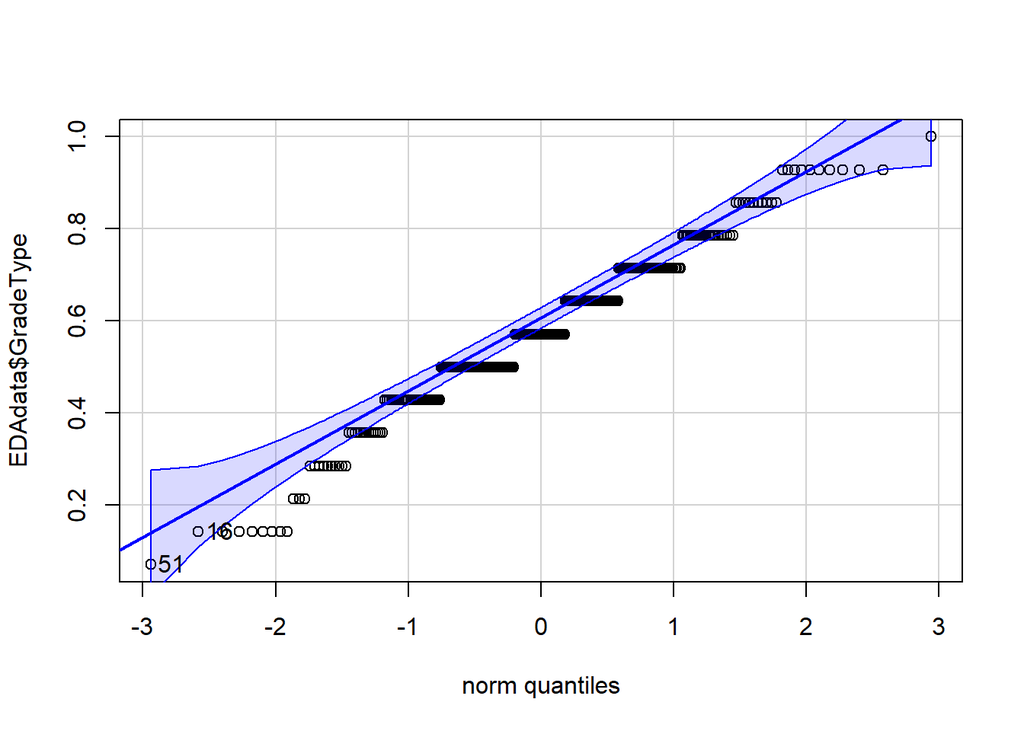

```
## [1] 51 16
```

```r
##QQ plot
car::qqPlot(EDAdata$`GradeType`)
```

## Outcome of Interest: Code Answer Performance

The last potential outcome of interest is the performance across survey questions that asked participants to identify the specific code for each hazard.

```r
#summary statistics
base::summary(EDAdata$`CodeScore`)
```

```
##    Min. 1st Qu.  Median    Mean 3rd Qu.    Max.
##  0.0000  0.2857  0.4286  0.4450  0.5714  1.0000
```

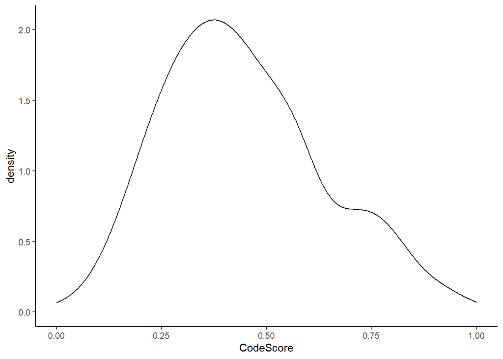

```r
#density plot
ggplot2::ggplot(data = EDAdata, aes(x = `CodeScore`)) +
  geom_density()
```

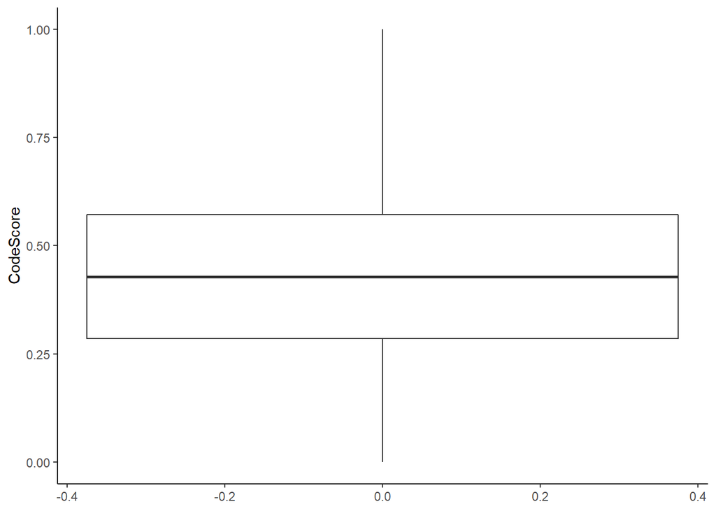

```r
#normal boxplot
ggplot2::ggplot(data = EDAdata, aes(y = `CodeScore`)) +
  geom_boxplot()
```

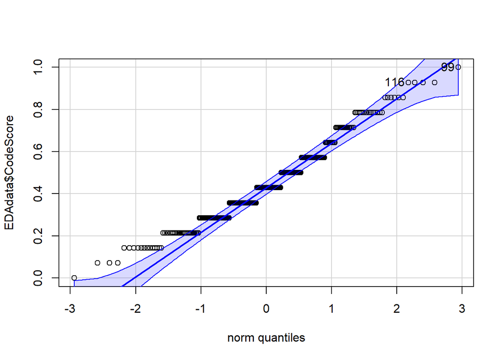

```
## [1]  99 116
```

```r
##QQ plot
car::qqPlot(EDAdata$`CodeScore`)
```

These outputs show the overall performance is relatively normally distributed. There really don’t seem to be any outliers, and it does not appear to require any transformation.